# Appendix-B

Afra Kilic, Supervisor: dr. ir. Joris Mulder

2023-07-30

## MCMC Model Search Method

In this part of the simulation, we will apply the Bayes factor presented for the variable selection for linear and nonlinear regression models. In Appendix-A, the consistency of the Bayes factor approximated via BIC is checked. However, when the number of candidate variables is large, exhaustive calculation of the posterior model probabilities for all possible models becomes infeasible. For instance, given $J=20$, there are more than three billions ($3^{20}$) possible models under consideration. This problem can be addressed by using MCMC model search method in the selection algorithm with different prior model probability setting.

A popular MCMC model search method was proposed by George and McCulloch (1993) for cases where the model space is large. The basic idea of the MCMC algorithm for Bayesian variable selection is to sequentially sample $\gamma$ from its posterior distribution, $\pi(\gamma|Y)$, and select the best model which appears most often in the sample of $\gamma$. When using conjugate priors the marginal posterior distribution of $\gamma$ has an analytical form:

$$\begin{equation}
\tag{1}
\pi(\gamma|Y) = P(M_\gamma|Y) \propto BF_{\gamma0}P(M_\gamma)
\end{equation}$$

where $BF_{\gamma0}$ is given in and $P(M_\gamma) = \frac{1}{3^J}$.

Gibbs sampler algorithm is only applied to $\gamma$, i.e.i to sequentially sample along $\gamma_p^t$ for $p=1, ..., J$ and $t= 1,...,T$ with T the iteration number:

$$\begin{equation}
\tag{2}
\gamma_{1}^{0},...,\gamma_{J}^{0}, \gamma_{1}^{1},...,\gamma_{J}^{1}, ..., \gamma_{1}^{t},...,\gamma_{J}^{t},...,
\end{equation}$$

where $\gamma_{1}^{0},...,\gamma_{P}^{0}$ denote the initial values, which can be set as zero. In the Gibbs algorithm the subsequent values of $\gamma_j^t$ can be sample from its conditional posterior distribution given the latest values of all other $\gamma$s.

The conditional distribution of $\gamma_j$ given all other $\gamma$s is Bernoulli. The three probabilities of sampling $\gamma_j^{t} = r$ for $r=0,1,2$ at iteration rate $t$ are

$$\begin{equation}
\tag{3}
P(\gamma^{t}_{j}= r|\gamma^{t}_{-j}, y) = \frac{\pi(\gamma^{t}_{j}= r|\gamma^{t}_{-j}, y)}{\sum_{r}\pi(\gamma^{t}_{j}= r|\gamma^{t}_{-j}, y)}
\end{equation}$$

where $\gamma^{t}_{-j} = (\gamma^t_1, ..., \gamma^{t}_{j-1},\gamma^{t-1}_{j+1},...,\gamma^{t-1}_{J})$ denotes the latest values of $\gamma$ except $\gamma_j$. Note that when sampling $\gamma_j^t, (\gamma_{t+1} + ... + \gamma_{J})$ have not been sampled at iteration $t$, and thus their values at the $t-1$ iteration are used. $\pi(\gamma^{t}_{j}= r|\gamma^{t}_{-j}, y)$ can be computed using Equation (1). However, regardless of the number of variables $J$, a fixed $P(M_\gamma)$ causes the algorithm to include more variables as $J$ increases. This phenomenon, called multiplicity, arises from multiple tests or comparison in variable selection. This is most obvious in orthogonal situation where $J$ independent tests on the effect type of the variable $x_j$ are performed. Therefore, for instance, at iteration rate $t$, three independent models are compared to test the effect type of variable $x_j$ on the outcome variable, and the prior model probabilities for each model will be $P(M_{\gamma_j}^t) = 1/3$. Regardless of $J$, $P(M_{\gamma_j}^t)$ remains the same at every iteration for each variable. However, $P(M_{\gamma_j}^t) = 1/3$ suggests a model size of $2J/3$ a priori since each variable has a probability of $2/3$ of being included (either as linear or nonlinear), and there are $J$ total number of variables. This problem remains in case of other fixed prior choices, therefore no fixed choice of prior which is independent from the total number of variables can adjust for multiplicity.

To correct for the multiplicity, we specify a Dirichlet distribution, ($\alpha_0$, $\alpha_1$, $\alpha_2$), for the prior probabilities of effect types. For variable $x_j$, prior probabilities of having nonlinear, linear and zero effects respectively are denoted by $p_{2}$, $p_{1}$ and $p_{0}$. $p_{2}+p_{1}+p_{0}=1$ and $\alpha_0$, $\alpha_1$, $\alpha_2$ are the corresponding parameters for the Dirichlet distribution. Hence, Equation (12) can be rewritten by correcting multiplicity via multiplying each $\pi(\gamma^{t}_{j}= r|\gamma^{t}_{-j}, y)$ with $p_r^t$:

$$\begin{equation}
\tag{4}
P(\gamma^{t}_{j}= r|\gamma^{t}_{-j}, p_r^t, Y) = \frac{\pi(\gamma^{t}_{j}= r|\gamma^{t}_{-j}, Y) p_r^t}{\sum_{r}(\pi(\gamma^{t}_{j}= r|\gamma^{t}_{-j}, Y)p_r^t)}
\end{equation}$$

where $p_r^t$ can be written as:

$$\begin{equation}
\tag{5}
p_r^t \sim dirichlet (\alpha_0^{t-1} + |G_0 ^{t-1}|, \alpha_1^{t-1} + |G_1^{t-1}|, \alpha_2^{t-1} + |G_2^{t-1}|)
\end{equation}$$

$G_0$, $G_1$, and $G_2$ are the numbers of variables of which the effect types are zero, linear and nonlinear respectively, and they are set to zero at $t=0$. Note that $G_0+G_1+G_2 = J$. First, three sampling probabilities, either $\gamma^{t}_{j} = 0$, $\gamma^{t}_{j} = 1$ or $\gamma^{t}_{j} = 2$ will be sampled using Equation (4). Thereafter, the algorithm visits the next $\gamma^{t}_{j+1}$. Once all $\gamma^t$ have been sampled, at the end of iteration $t$, the algorithm samples for $p_r^{t+1}$ using the resulted $\gamma^t$. Then, the algorithm proceeds to the $t+1$ iteration and sample for the next $\gamma^{t+1}$ with updated prior probabilities, $p_r^{t+1}$, until the Gibbs chain converges to obtain the samples shown in (2). After obtaining the Gibbs samples and discarding the burn-in phase (e.g., the first 1000 iterations), the best model will be the one with the highest frequency in the useful samples.

**Gibbs Sampler Algorithm:** in total $3 \times P \times T$ model fit

Initialize $\gamma^{0} = 0$ and $p_r^0= 1/3$ at $t=0$

**repeat**

$\qquad$for $p = 1,..., J$ do

$\qquad$ $\qquad$ Sample $\gamma^{t} = 0$ with probability $P(\gamma^{t}_{j}= 0|\gamma^{t}_{-j}, p_r^t,Y)$

$\qquad$ $\qquad$ Sample $\gamma^{t} = 1$ with probability $P(\gamma^{t}_{j}= 1|\gamma^{t}_{-j},p_r^t, Y)$

$\qquad$ $\qquad$ Sample $\gamma^{t} = 2$ with probability $P(\gamma^{t}_{j}= 2|\gamma^{t}_{-j},p_r^t, Y)$

**end for**

$\qquad$ Sample $p_r^{t+1}$ with probability $dirichlet(\alpha_0^t + |G_0^t|, \alpha_1^t + |G_1^t|, \alpha_2^t + |G_2^t|)$

**set** $t=t+1$

**until** Gibbs chain converges.

## Performance of the Model Search Method

$$\begin{equation}
\tag{6}
y = \beta exp(x_1) + \beta exp(x_2) + \beta x_3 + \beta x_4 + \beta^0 X_{J-4} + \epsilon
\end{equation}$$

where $\beta^0 = 0$, $\epsilon \sim N(0, \sigma^2)$ and $\sigma^2 = .1$. Thus, the first two variables exhibit a nonlinear effect, the next two variables have a linear effect, and the remaining variables have no effect on the outcome variable.

The following function function `bayesian_selection` generates the model in (6) using the specified parameters as input variables. Then it applies the variable selection algorithm using MCMC model search method with the specified number of iteration which is 1000 in this simulation.

It returns a list including the following values:

- Is the selected model the same with the true model. 1: Yes and 0: No
- Posterior probability of the true model
- Posterior probability of the selected model
- Selected model
- True model
- $\gamma$ draws in (2)
- $p_r$ draws in (5)

Input variables:

- `beta`: $\beta$
- `n`: sample size $n$
- `knots`: k (number of basis function = k-1)
- `n_var`: total number of variables $J$
- `iteration`: burn-in
- `gamma_prior`: initial $\gamma$ values ($\gamma_{1}^{0},...,\gamma_{P}^{0}$)
- `prior_p`: initial $p_r$ values ($p_r^0$)

```r
bayesian_selection<- function(beta = 0.8, n = 100,
                                sigma2 = 0.1, n_var = 10,
                                knots= 4,
                                iteration=1000,
                                gamma_prior = c(rep(0, n_var)),
                                prior_p=c(1/3, 1/3, 1/3)){

  #penalty is calculated as max edf - df(lm) for each variable swhere max edf = k-1 and df(lm)=1
  penalty=knots-2
  #Data Generation
  #independent predictor variables
  variables <- matrix(NA, nrow=n, ncol=n_var)
  colnames(variables) <-c(paste0("x", 1:n_var))
  for (i in 1:n_var){
    variables[,i] = rnorm(n)
  }
  #outcome variable
  error <- rnorm(n,sd=sqrt(sigma2)); y=error

  #randomly selecting the nonlinears and the zero relationships
  nonlinear_true <- c("x1", "x2")
  linear_true <- c("x3", "x4")
  zero_true <- setdiff(colnames(variables), c(nonlinear_true, linear_true))

  # relationship definitions and creating the true model
  #nonlinear effects
  nonlinear_indices <- match(nonlinear_true, colnames(variables))
  for(i in 1:length(nonlinear_indices)){y=y+beta*exp(variables[, nonlinear_indices][,i])}

  #zero effects
  zero_indices <- match(zero_true, colnames(variables))
  for(i in 1:length(zero_indices)){y=y+0*variables[,zero_indices][,i]}

  #linear effects
  linear_indices<- match(linear_true, colnames(variables))
  for(i in 1: length(linear_indices)){y=y+beta*variables[,linear_indices][,i]}

  y = y - mean(y) #not considering the intercept

  #true model gamma sequence
  true_gamma = c(rep(NA, n_var))
  true_gamma[nonlinear_indices]=2; true_gamma[zero_indices]=0; true_gamma[linear_indices]=1
  data_original<- as.data.frame(variables) #transforming the matrix into a dataframe

  gamma_update_k <-gamma_prior #initial gamma specification
  gamma_draws <- matrix(NA, nrow= iteration, ncol = n_var) #matrix for gamma draws
  ps<- matrix(NA, nrow = iteration+1, ncol = 3) #matrix for p_draws

  pb<-progress_bar$new(format = "(:spin) [:bar] :percent [Elapsed time: :elapsedfull || Estimated time remaining: :eta]",
                       total = iteration,
                       complete = "=",   # Completion bar character
                       incomplete = "-", # Incomplete bar character
                       current = ">",    # Current bar character
                       clear = FALSE,    # If TRUE, clears the bar when finish
                       width = 100)      # Width of the progress bar
  for(s in 1:iteration){
    pb$tick()
    for(k in 1:n_var){
      data = data_original
      gamma_update_k1 <- gamma_update_k[-c(k)]

      a <- data[, k] #the variable of interest
      data <- data[, -k] #the remaining variables

      # for linear effects
      linears <- c()
      if(length(gamma_update_k1[gamma_update_k1 == 1]) != 0){

        for(i in 1:ncol(data[which(gamma_update_k1 == 1)])){
          linears <- c(linears, paste(c(colnames(data[which(gamma_update_k1 == 1)][i])), collapse= ""))
        }
      }

      #for nonlinear effects
      non_linears <- c()
      if(length(gamma_update_k1[gamma_update_k1 == 2]) != 0) {
        for(i in 1:ncol(data[which(gamma_update_k1 == 2)])){
          non_linears <- c(non_linears, paste(c('s(', colnames(data[which(gamma_update_k1 == 2)][i]), ',k=',knots,')'), collapse= ""))
        }
      }

      vars <- c(linears, non_linears) #vector for non-zero effects to include to the models below

      #model fitting
      if(length(vars) != 0){ #remaining variables contain non-zero effect
        M1 <- gam(as.formula(paste('y', '~', paste(vars, collapse =  "+"))), data = data)
        M2 <- gam(as.formula(paste('y',  '~', 'a +', paste(vars, collapse =  "+"))), data = data) #1
        M3 <- gam(as.formula(paste('y',  '~', 's(a, k=',knots, ') +', paste(vars, collapse =  "+"))), data = data) #2
      } else{ #remaining variables do not contain non-zero effect
        M1 <- gam(y ~ 1, data = data)
        M2 <- gam(y ~ a, data = data) #1
        M3 <- gam(y ~ s(a, k=knots), data = data)
      }

      #BIC scores
      bic_M1 <- (-2) * head(logLik(M1)) +  attr(logLik(M1), "df")* log(n)
      bic_M2 <- (-2) * head(logLik(M2)) +  attr(logLik(M2), "df")* log(n)
      bic_M3 <- (-2) * head(logLik(M3)) +  (attr(logLik(M2), "df") + penalty)* log(n) #penalty depends on the #of knots


      #Bayes Factors
      BF11 <- exp((bic_M1 - bic_M1) /2) #null against the null
      BF21_ <- exp((bic_M1 - bic_M2) /2) #linear against the null
      BF31_ <- exp((bic_M1 - bic_M3) /2) #nonlinear against the null


      #infinity BFs
      if(BF21_ == "-Inf"){BF21 = -1e5} else if(BF21_== "Inf") {BF21 = 1e5} else{BF21=BF21_}
      if(BF31_ == "-Inf"){BF31 = -1e5} else if(BF31_ == "Inf") {BF31 = 1e5} else{BF31=BF31_}

      #Posterior Probabilities
      zero <- (prior_p[1] * BF11) / sum(prior_p[1] * BF11, prior_p[2]*BF21, prior_p[3]* BF31)
      one <- (prior_p[2] * BF21) / sum(prior_p[1] * BF11, prior_p[2]*BF21, prior_p[3]* BF31)
      two <- (prior_p[3] * BF31) / sum(prior_p[1] * BF11, prior_p[2]*BF21, prior_p[3]* BF31)



      #sampling the effect type of the variable of interest
      gamma_update_k[k] <- sample(c(0,1,2), size=1, prob = c(zero, one, two))
    }

    #multiplicity correction for the next chain
    prior_p <- rdirichlet(1, c(1+length(gamma_update_k[which(gamma_update_k == 0)]), #alpha1 = 1
                               1+length(gamma_update_k[which(gamma_update_k == 1)]),  #alpha2 = 1
                               1+length(gamma_update_k[which(gamma_update_k == 2)])))
    ps[s+1, ] <- prior_p
    gamma_draws[s,] <- gamma_update_k
  }
  #posterior probability calculation of the true model
  posterior <- data.table(gamma_draws)
  frequency <- as.matrix(posterior[,list(posterior=.N),by=names(posterior)][order(posterior,decreasing=T)])
  t=apply(frequency[,-(n_var+1)], 1, function(x) return(all(x == true_gamma))) #checking any true model among the draws
  pp_t<- if (any(t)==FALSE) 0 else as.numeric(frequency[which(t),(n_var+1)])/iteration ##posterior prob calculation of the true
  pp_s <- as.numeric(frequency[1,(n_var+1)])/iteration ##posterior prob calculation of the selected
  results <- list("is true" = if(identical(as.vector(frequency[1,1:n_var]),true_gamma) == TRUE) 1 else 0,
                  "posterior probability_true" = pp_t,
                  "posterior probability_selected" = pp_s,
                  "selected model" = as.vector(frequency[1,1:n_var]),
                  "true model" = true_gamma,
                  "gamma draws" = gamma_draws,
                  "p draws" = ps)
  return(results)
}
```

### Convergence of Gibbs sampler chain

To start, we need to discard the initial burn-in phase and ensure the convergence of the chain. Monitoring the sample of $\gamma$, which is a vector of discrete variables that fluctuates in the chain, is not recommended. Instead, we monitor the largest posterior probability among all possible models given the current sample since it serves as the criterion for selecting the best model. To check the Gibbs sampler chain, we examine every 100 samples. For instance, if in the first 100 samples, $M_\gamma$ appears most frequently, say 40 times, then the probability is 0.4. Subsequently, if for the first 200 samples, M0c0 (which is often the same as $M_\gamma$) has the largest count, say 100, then the probability becomes 0.5. As the number of iterations in the Gibbs sampler increases, the largest posterior probability should converge to a certain value, allowing us to confidently select the best model.

### J=6

```r
chain_6 <- bayesian_selection_m(iteration = 10000, n_var = 6) #fit

chain_6_pp <- c(rep(NA, 100))#matrix to store the posterior probabilities at every 100 iteration
for (i in 1:100){
  gamma_draws <- chain_6$`gamma draws`
  posterior <- data.table(gamma_draws[1:(i*100),])
  frequency <- as.matrix(posterior[,list(posterior=.N),by=names(posterior)][order(posterior,decreasing=T)])
  pp_s <- as.numeric(frequency[1,(6+1)])/(i*100) ##posterior prob calculation of the selected
  chain_6_pp[i] = pp_s
}
```

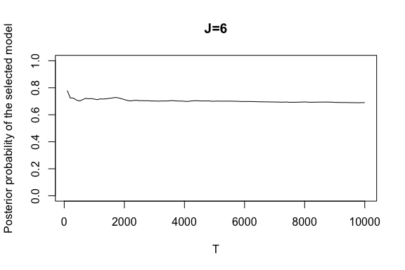

```r
plot(c(100*c(1:100)), chain_6_pp, type="l", ylim=c(0, 1),
     ylab = "Posterior probability of the selected model", xlab = "T", main = "J=6")
```

### J=20

```r
chain_20 <- bayesian_selection_m(iteration = 10000, n_var = 20) #fit

chain_20_pp <- c(rep(NA, 100))#matrix to store the posterior probabilities at every 100 iteration
for (i in 1:100){
  gamma_draws <- chain_20$`gamma draws`
  posterior <- data.table(gamma_draws[1:(i*100),])
  frequency <- as.matrix(posterior[,list(posterior=.N),by=names(posterior)][order(posterior,decreasing=T)])
  pp_s <- as.numeric(frequency[1,(20+1)])/(i*100) ##posterior prob calculation of the selected
  chain_20_pp[i] = pp_s
}
```

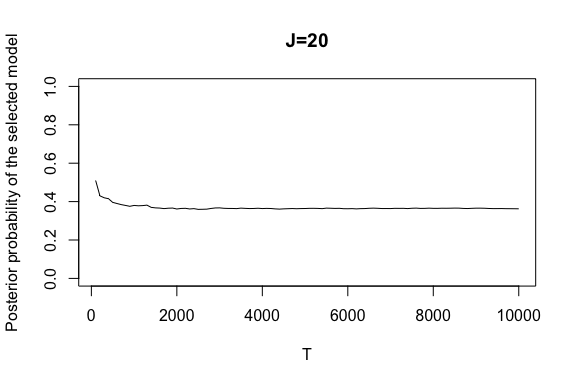

```r
plot(c(100*c(1:100)), chain_20_pp, type="l", ylim=c(0, 1),
     ylab = "Posterior probability of the selected model", xlab = "T", main = "J=20")
```

```r
# Run the loop in parallel
detectCores()
registerDoParallel(30)
trials=100
```

### Sample Size $n$

- The sample size varied from $n=50$ to $n=500$ given $\beta = .5$ and $\beta = 2$ for $J=10$

```r
####SAMPLE SIZES
xresults_n50 <- foreach(icount(trials),
                        .packages = c("mgcv", "data.table", "MCMCprecision", "lubridate", "progress"),
                        .combine = rbind) %dopar%{
                          # set the specific values of the parameters
                          a = bayesian_selection(beta=.5, n=50)
                          b = bayesian_selection(beta=2, n=50)

                          c(a$`is true`, a$`posterior probability_true`,a$`posterior probability_selected`,
                            a$`selected model`,
                            b$`is true`, b$`posterior probability_true`,b$`posterior probability_selected`,
                            b$`selected model`)
                        }

xresults_n100 <- foreach(icount(trials),
                         .packages = c("mgcv", "data.table", "MCMCprecision", "lubridate", "progress"),
                         .combine = rbind) %dopar%{
                           # set the specific values of the parameters
                           a = bayesian_selection(beta=.5, n=100)
                           b = bayesian_selection(beta=2, n=100)

                           c(a$`is true`, a$`posterior probability_true`,a$`posterior probability_selected`,
                             a$`selected model`,
                             b$`is true`, b$`posterior probability_true`,b$`posterior probability_selected`,
                             b$`selected model`)
                         }

xresults_n250 <- foreach(icount(trials),
                          .packages = c("mgcv", "data.table", "MCMCprecision", "lubridate", "progress"),
                          .combine = rbind) %dopar%{
                            # set the specific values of the parameters
                            a = bayesian_selection(beta=.5, n=250)
                            b = bayesian_selection(beta=2, n=250)

                            c(a$`is true`, a$`posterior probability_true`,a$`posterior probability_selected`,
                              a$`selected model`,
                              b$`is true`, b$`posterior probability_true`,b$`posterior probability_selected`,
                              b$`selected model`)
                          }

xresults_n500 <- foreach(icount(trials),
                         .packages = c("mgcv", "data.table", "MCMCprecision", "lubridate", "progress"),
                         .combine = rbind) %dopar%{
                           # set the specific values of the parameters
                           a = bayesian_selection(beta=.5, n=500)
                           b = bayesian_selection(beta=2, n=500)

                           c(a$`is true`, a$`posterior probability_true`,a$`posterior probability_selected`,
                             a$`selected model`,
                             b$`is true`, b$`posterior probability_true`,b$`posterior probability_selected`,
                             b$`selected model`)
                         }
```

#### Plots

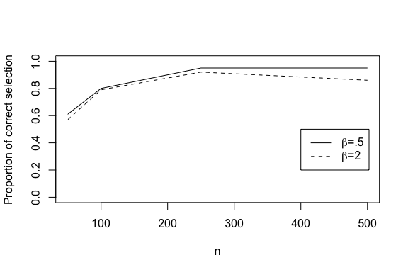

```r
#proportion of correct selection

#beta=.5
cs_n_.5 <- c(length(n50[,1][n50[,1]==1]),
                 length(n100[,1][n100[,1]==1]),
                 length(n250[,1][n250[,1]==1]),
                 length(n500[,1][n500[,1]==1]))

#beta=2
cs_n_2 <- c(length(n50[,14][n50[,14]==1]),
             length(n100[,14][n100[,14]==1]),
             length(n250[,14][n250[,14]==1]),
             length(n500[,14][n500[,14]==1]))

#plot
plot(c( 50, 100, 250, 500), cs_n_.5/100, type="l", ylim=c(0, 1),
     ylab = "Proportion of correct selection", xlab = "n")
legend(400, 0.5, legend=c(expression(paste(beta, "=.5")), expression(paste(beta, "=2"))),
       lty=1:2, cex=1)
lines(c( 50, 100, 250, 500), cs_n_2/100, type="l", lty=2)
```

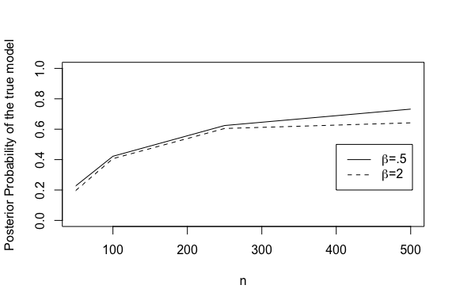

```r
#posterior probability of the true model

#beta=.5
pp_n_.5 <-c(mean(n50[,2]),
             mean(n100[,2]),
             mean(n250[,2]),
             mean(n500[,2])) #
#beta=2
pp_n_2 <- c(mean(n50[,15]),
             mean(n100[,15]),
             mean(n250[,15]),
             mean(n500[,15]))

#plot
plot(c( 50, 100, 250, 500), pp_n_.5, type="l", ylim=c(0, 1),
     ylab = "Posterior Probability of the true model", xlab = "n")
legend(400, 0.5, legend=c(expression(paste(beta, "=.5")), expression(paste(beta, "=2"))),
       lty=1:2, cex=1)
lines(c( 50, 100, 250, 500), pp_n_2, type="l", lty=2)
```

### Effect Size $\beta$

- The effect size varied from $\beta = .1$ to $\beta = 3$ given $n=100$ and $n=250$ for $J=10$.

```r
#beta=0.1
xresults_beta_.1 <- foreach(icount(trials),
                            .packages = c("mgcv", "data.table", "MCMCprecision", "lubridate", "progress"),
                            .combine = rbind) %dopar%{
                              # set the specific values of the parameters
                              a = bayesian_selection(beta=.1, n=100)
                              b = bayesian_selection(beta=.1, n=250)

                              c(a$`is true`, a$`posterior probability_true`,a$`posterior probability_selected`,
                                a$`selected model`,
                                b$`is true`, b$`posterior probability_true`,b$`posterior probability_selected`,
                                b$`selected model`)
                            }



#beta=0.5
xresults_beta_.5 <- foreach(icount(trials),
                            .packages = c("mgcv", "data.table", "MCMCprecision", "lubridate", "progress"),
                            .combine = rbind) %dopar%{
                              # set the specific values of the parameters
                              a = bayesian_selection(beta=.5, n=100)
                              b = bayesian_selection(beta=.5, n=250)

                              c(a$`is true`, a$`posterior probability_true`,a$`posterior probability_selected`,
                                a$`selected model`,
                                b$`is true`, b$`posterior probability_true`,b$`posterior probability_selected`,
                                b$`selected model`)
                            }



#beta=0.1
xresults_beta_1 <- foreach(icount(trials),
                            .packages = c("mgcv", "data.table", "MCMCprecision", "lubridate", "progress"),
                            .combine = rbind) %dopar%{
                              # set the specific values of the parameters
                              a = bayesian_selection(beta=1, n=100)
                              b = bayesian_selection(beta=1, n=250)

                              c(a$`is true`, a$`posterior probability_true`,a$`posterior probability_selected`,
                                a$`selected model`,
                                b$`is true`, b$`posterior probability_true`,b$`posterior probability_selected`,
                                b$`selected model`)
                            }



#beta=0.1
xresults_beta_1.5 <- foreach(icount(trials),
                            .packages = c("mgcv", "data.table", "MCMCprecision", "lubridate", "progress"),
                            .combine = rbind) %dopar%{
                              # set the specific values of the parameters
                              a = bayesian_selection(beta=1.5, n=100)
                              b = bayesian_selection(beta=1.5, n=250)

                              c(a$`is true`, a$`posterior probability_true`,a$`posterior probability_selected`,
                                a$`selected model`,
                                b$`is true`, b$`posterior probability_true`,b$`posterior probability_selected`,
                                b$`selected model`)
                            }




#beta=0.1
xresults_beta_2 <- foreach(icount(trials),
                            .packages = c("mgcv", "data.table", "MCMCprecision", "lubridate", "progress"),
                            .combine = rbind) %dopar%{
                              # set the specific values of the parameters
                              a = bayesian_selection(beta=2, n=100)
                              b = bayesian_selection(beta=2, n=250)

                              c(a$`is true`, a$`posterior probability_true`,a$`posterior probability_selected`,
                                a$`selected model`,
                                b$`is true`, b$`posterior probability_true`,b$`posterior probability_selected`,
                                b$`selected model`)
                            }



xresults_beta_2.5 <- foreach(icount(trials),
                           .packages = c("mgcv", "data.table", "MCMCprecision", "lubridate", "progress"),
                           .combine = rbind) %dopar%{
                             # set the specific values of the parameters
                             a = bayesian_selection(beta=2.5, n=100)
                             b = bayesian_selection(beta=2.5, n=250)

                             c(a$`is true`, a$`posterior probability_true`,a$`posterior probability_selected`,
                               a$`selected model`,
                               b$`is true`, b$`posterior probability_true`,b$`posterior probability_selected`,
                               b$`selected model`)
                           }


xresults_beta_3 <- foreach(icount(trials),
                           .packages = c("mgcv", "data.table", "MCMCprecision", "lubridate", "progress"),
                           .combine = rbind) %dopar%{
                             # set the specific values of the parameters
                             a = bayesian_selection(beta=3, n=100)
                             b = bayesian_selection(beta=3, n=250)

                             c(a$`is true`, a$`posterior probability_true`,a$`posterior probability_selected`,
                               a$`selected model`,
                               b$`is true`, b$`posterior probability_true`,b$`posterior probability_selected`,
                               b$`selected model`)
                           }
```

#### Plots

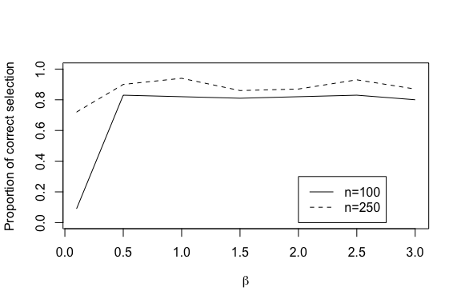

```r
#proportion of correct selection

#n=100
cs_beta_100 <- c(length(beta.1[,1][beta.1[,1]==1]),
                 length(beta.5[,1][beta.5[,1]==1]),
                 length(beta1[,1][beta1[,1]==1]),
                 length(beta1.5[,1][beta1.5[,1]==1]),
                 length(beta2[,1][beta2[,1]==1]),
                 length(beta2.5[,1][beta2.5[,1]==1]),
                 length(beta3[,1][beta3[,1]==1]))

#n=250
cs_beta_250 <- c(length(beta.1[,14][beta.1[,14]==1]),
                 length(beta.5[,14][beta.5[,14]==1]),
                 length(beta1[,14][beta1[,14]==1]),
                 length(beta1.5[,14][beta1.5[,14]==1]),
                 length(beta2[,14][beta2[,14]==1]),
                 length(beta2.5[,14][beta2.5[,14]==1]),
                 length(beta3[,14][beta3[,14]==1]))



#plot
plot(c( .1,.5,1, 1.5, 2, 2.5, 3), cs_beta_100/100, type="l", ylim=c(0, 1),
     ylab = "Proportion of correct selection", xlab = expression(beta))
legend(2, 0.3, legend=c("n=100", "n=250"),
       lty=1:2, cex=1)
lines(c( .1,.5,1, 1.5, 2, 2.5, 3), cs_beta_250/100, type="l", lty=2)
```

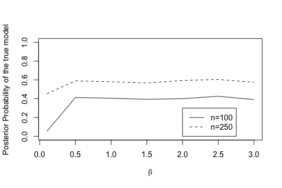

```r
#posterior probability of the true model

#n=100
pp_beta_100 <- c(mean(beta.1[,2]),
                 mean(beta.5[,2]),
                 mean(beta1[,2]),
                 mean(beta1.5[,2]),
                 mean(beta2[,2]),
                 mean(beta2.5[,2]),
                 mean(beta3[,2]))

#n=250
pp_beta_250 <- c(mean(beta.1[,15]),
                 mean(beta.5[,15]),
                 mean(beta1[,15]),
                 mean(beta1.5[,15]),
                 mean(beta2[,15]),
                 mean(beta2.5[,15]),
                 mean(beta3[,15]))

#plot
plot(c( .1,.5,1, 1.5, 2, 2.5, 3), pp_beta_100, type="l", ylim=c(0, 1),
     ylab = "Posterior Probability of the true model", xlab = expression(beta))
legend(2, 0.3, legend=c("n=100", "n=250"),
       lty=1:2, cex=1)
lines(c( .1,.5,1, 1.5, 2, 2.5, 3), pp_beta_250, type="l", lty=2)
```

### Number of variables (J)

- $J$ varied from $J=6$ to $J=30$ given `k=4`.

```r
start <- proc.time()
mj6 <- foreach(icount(100),
               .packages = c("mgcv", "data.table", "MCMCprecision", "lubridate", "progress"),
               .combine = rbind) %dopar%{
                 # set the specific values of the parameters
                 a = bayesian_selection(n_var=6)


                 c(a$`is true`, a$`posterior probability_true`,a$`posterior probability_selected`,
                   a$`selected model`)
               }

mj6_CPU <- proc.time()-start

######################################################################################################

start <- proc.time()
mj10 <- foreach(icount(100),
                .packages = c("mgcv", "data.table", "MCMCprecision", "lubridate", "progress"),
                .combine = rbind) %dopar%{
                  # set the specific values of the parameters
                  a = bayesian_selection(n_var=10)


                  c(a$`is true`, a$`posterior probability_true`,a$`posterior probability_selected`,
                    a$`selected model`)
                }

mj10_CPU <- proc.time()-start


######################################################################################################
start <- proc.time()
mj20 <- foreach(icount(100),
                .packages = c("mgcv", "data.table", "MCMCprecision", "lubridate", "progress"),
                .combine = rbind) %dopar%{
                  # set the specific values of the parameters
                  a = bayesian_selection(n_var=20)


                  c(a$`is true`, a$`posterior probability_true`,a$`posterior probability_selected`,
                    a$`selected model`)
                }

mj20_CPU <- proc.time()-start

######################################################################################################

start <- proc.time()
mj15 <- foreach(icount(100),
                .packages = c("mgcv", "data.table", "MCMCprecision", "lubridate", "progress"),
                .combine = rbind) %dopar%{
                  # set the specific values of the parameters
                  a = bayesian_selection(n_var=15)


                  c(a$`is true`, a$`posterior probability_true`,a$`posterior probability_selected`,
                    a$`selected model`)
                }

mj15_CPU <- proc.time()-start

######################################################################################################

start <- proc.time()
mj30 <- foreach(icount(100),
                .packages = c("mgcv", "data.table", "MCMCprecision", "lubridate", "progress"),
                .combine = rbind) %dopar%{
                  # set the specific values of the parameters
                  a = bayesian_selection(n_var=30)


                  c(a$`is true`, a$`posterior probability_true`,a$`posterior probability_selected`,
                    a$`selected model`)
                }

mj30_CPU <- proc.time()-start
```

```r
#proportion of correct selection & posterior probability of the true model
J <- cbind(c(length(mj6[,1][mj6[,1]==1]), length(mj10[,1][mj10[,1]==1]),
             length(mj15[,1][mj15[,1]==1]),length(mj20[,1][mj20[,1]==1]),
             length(mj30[,1][mj30[,1]==1])), #proportion of correct selection

           c(mean(mj6[,2]), mean(mj10[,2]), mean(mj15[,2]), mean(mj20[,2]), mean(mj30[,2])),#posterior prob

           c(mj6_CPU, mj10_CPU, mj15_CPU, mj20_CPU, mj30_CPU)/mj10_CPU) #CPU

colnames(J) = c("Correct Selection Proportion", "Posterior Pr. of the true model", "CPU")
rownames(J) = c("J=6", "J=10", "J=15", "J=20", "J=30")

J
```

```
##      Correct Selection Proportion Posterior Pr. of the true model       CPU
## J=6                            83                         0.47845 0.5845953
## J=10                           80                         0.40664 1.0000000
## J=15                           79                         0.36570 1.5324259
## J=20                           77                         0.35100 2.0809754
## J=30                           74                         0.29993 3.3697361
```

#### Multiplicity check

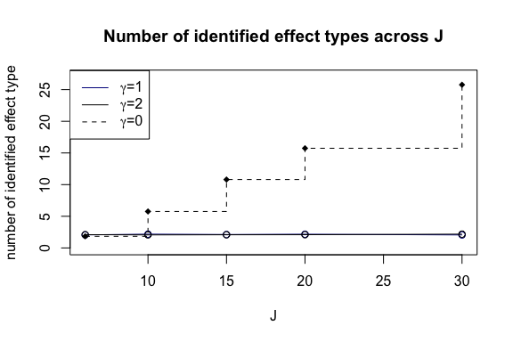

```r
multiplicity <- matrix(NA, ncol = 3, nrow = 5)
mj_results <- list(mj6, mj10, mj15, mj20, mj30)
for (i in 1:5){
  no_var <- matrix(NA, nrow = 100, ncol = 3)
  for (j in 1:100){
    result <- mj_results[[i]]
    no_var[j,] <- c(length(result[j,-c(1:3)][result[j,-c(1:3)]==1]), #gamma=1
                    length(result[j,-c(1:3)][result[j,-c(1:3)]==2]), #gamma=2
                    length(result[j,-c(1:3)][result[j,-c(1:3)]==0])) #gamma=0
  }
  multiplicity[i,] <- colMeans(no_var)
}


#plot
plot(c(6, 10, 15, 20, 30), multiplicity[,1], type = "o", col = "darkblue",  ylim = c(0,27),#gamma=1
     main="Number of identified effect types across J", xlab="J", ylab="number of identified effect type")
lines(c(6, 10, 15, 20, 30), multiplicity[,2], type = "o") #gamma=2
lines(c(6, 10, 15, 20, 30), multiplicity[,3], type = "s", lty = 2, pch = 15) #gamma=0
points(c(6, 10, 15, 20, 30), multiplicity[,3], pch = 18) #points for gamma=0
legend(5, 28, legend=c(expression(paste(gamma, "=1")), expression(paste(gamma, "=2")), expression(paste(gamma, "=0"))),
       col = c("darkblue", "black", "black"), lty=c(1,1,2), cex=1 )
```

### Number of basis function (knots)

- `k` varied from `k = 4` to `k=12` given $J=10$

```r
#KNOTS
start <- proc.time()
knots4 <- foreach(icount(100),
                 .packages = c("mgcv", "data.table", "MCMCprecision", "lubridate", "progress"),
                 .combine = rbind) %dopar%{
                   # set the specific values of the parameters
                   a = bayesian_selection(nots=4)


                   c(a$`is true`, a$`posterior probability_true`,a$`posterior probability_selected`,
                     a$`selected model`)
                 }

write.csv(nots4, "nots4.csv")
knots4_CPU <- proc.time()-start

######################################################################################################

start <- proc.time()
knots6 <- foreach(icount(100),
                 .packages = c("mgcv", "data.table", "MCMCprecision", "lubridate", "progress"),
                 .combine = rbind) %dopar%{
                   # set the specific values of the parameters
                   a = bayesian_selection(nots=6)

                   c(a$`is true`, a$`posterior probability_true`,a$`posterior probability_selected`,
                     a$`selected model`)
                 }

write.csv(nots6, "nots6.csv")
knots6_CPU <- proc.time()-start

######################################################################################################

start <- proc.time()
knots8 <- foreach(icount(100),
                 .packages = c("mgcv", "data.table", "MCMCprecision", "lubridate", "progress"),
                 .combine = rbind) %dopar%{
                   # set the specific values of the parameters
                   a = bayesian_selection(nots=8)


                   c(a$`is true`, a$`posterior probability_true`,a$`posterior probability_selected`,
                     a$`selected model`)
                 }

write.csv(nots8, "nots8.csv")
knots8_CPU <- proc.time()-start

######################################################################################################

start <- proc.time()
knots10 <- foreach(icount(100),
                  .packages = c("mgcv", "data.table", "MCMCprecision", "lubridate", "progress"),
                  .combine = rbind) %dopar%{
                    # set the specific values of the parameters
                    a = bayesian_selection(nots=10)


                    c(a$`is true`, a$`posterior probability_true`,a$`posterior probability_selected`,
                      a$`selected model`)
                  }

knots10_CPU <- proc.time()-start

######################################################################################################

start <- proc.time()
knots12 <- foreach(icount(100),
                  .packages = c("mgcv", "data.table", "MCMCprecision", "lubridate", "progress"),
                  .combine = rbind) %dopar%{
                    # set the specific values of the parameters
                    a = bayesian_selection(nots=12)


                    c(a$`is true`, a$`posterior probability_true`,a$`posterior probability_selected`,
                      a$`selected model`)
                  }

knots12_CPU <- proc.time()-start
```

```r
#proportion of correct selection & posterior probability of the true model
knots <- cbind(c(length(knots4[,1][knots4[,1]==1]), length(knots6[,1][knots6[,1]==1]),
                 length(knots8[,1][knots8[,1]==1]),length(knots10[,1][knots10[,1]==1]),
                 length(knots12[,1][knots12[,1]==1])),

               c(mean(knots4[,2]), mean(knots6[,2]),
                 mean(knots8[,2]), mean(knots10[,2]), mean(knots12[,2])),
               c(mj10_CPU, knots6_CPU, knots8_CPU, knots10_CPU, knots12_CPU)/mj10_CPU) #CPU

colnames(knots) = c("Correct Selection Proportion", "Posterior Pr. of the true model", "CPU")

rownames(knots) = c("k=4", "k=6", "k=8", "k=10", "k=12")

knots
```

```
##      Correct Selection Proportion Posterior Pr. of the true model      CPU
## k=4                            80                         0.39141 1.000000
## k=6                            90                         0.47933 1.073843
## k=8                            91                         0.50552 1.134789
## k=10                           86                         0.44465 1.225528
## k=12                           84                         0.42447 1.437921
```

### References

- George, E. I., & McCulloch, R. E. (1993). Variable selection via Gibbs sampling. Journal of the American Statistical Association, 88(423), 881–889. https://doi.org/10.1080/01621459.1993.10476353